# Boris Bikes - A Data-Powered Journey

## Introduction

> I decided to use a dataset produced by Transport for London (TfL) which details the use of the city's biycle hire scheme, which are currently branded as Santander Cycles, after the bank Santander who currently sponsor them. To me and many other Londoners of my generation, they will always be Boris Bikes, and I will refer to them as such henceforce.

> TfL is London's transport authority, who have remit for all travel matters across the city. Like many government bodies they are making the data their operations accumulate available for public use, and Boris Bike data is accessible via this link: https://cycling.data.tfl.gov.uk/

> TfL require me to adhere to terms and conditions which apply to this data. I can confirm I am in compliance with these, and details can be found here: https://tfl.gov.uk/corporate/terms-and-conditions/transport-data-service

## Setup

```python
import pandas as pd
import matplotlib.pyplot as plt
import seaborn as sb
import numpy as np
from bs4 import BeautifulSoup
import os, sys
import requests

%matplotlib inline
```

## Gathering Data

From https://cycling.data.tfl.gov.uk/ I have saved and modified the main html file to access all of the urls. From this I will extract the urls, save them to a list and then request the files for download to my local machine.

```python
with open("./cycling.data.tfl.gov.uk_modified.html") as file:
    soup = BeautifulSoup(file, 'html.parser')
```

```python
url_list = []
```

```python
for link in soup.find_all('a'):
    url_list.append(link.get('href'))
```

```python
url_2019_list = []
```

```python
for url in url_list:
    if url.endswith('2019.csv'):
        url_2019_list.append(url)
```

```python
url_2019_list[0:5]
```

```
['https://cycling.data.tfl.gov.uk/usage-stats/142JourneyDataExtract26Dec2018-01Jan2019.csv',
 'https://cycling.data.tfl.gov.uk/usage-stats/143JourneyDataExtract02Jan2019-08Jan2019.csv',
 'https://cycling.data.tfl.gov.uk/usage-stats/144JourneyDataExtract09Jan2019-15Jan2019.csv',
 'https://cycling.data.tfl.gov.uk/usage-stats/145JourneyDataExtract16Jan2019-22Jan2019.csv',
 'https://cycling.data.tfl.gov.uk/usage-stats/146JourneyDataExtract23Jan2019-29Jan2019.csv']
```

```python
# Download 2019 csv's
# **CAUTION - Running this cell takes considerable time. Total size of files downloaded = 1.3gb

# Make directory if it doesn't already exist
folder_name = 'source_data_2019'
if not os.path.exists(folder_name):
    os.makedirs(folder_name)

for url in url_2019_list:

    #We'll use the Requests library to get the url
    response = requests.get(url)

    #Open/create a file in folder_name
    #Use python.split to name the file, everything after the last slash in the url
    #Open the file in write binary mode
    with open(os.path.join(folder_name, url.split('/',)[-1]), mode = "wb") as file:

        #Contents is everything in the response variable
        file.write(response.content)
        print("File completed: ",file)
```

```python
url_2020_list = []

for url in url_list:
    if url.endswith('2020.csv'):
        url_2020_list.append(url)

url_2020_list[0:5]
```

```
['https://cycling.data.tfl.gov.uk/usage-stats/195JourneyDataExtract01Jan2020-07Jan2020.csv',
 'https://cycling.data.tfl.gov.uk/usage-stats/196JourneyDataExtract08Jan2020-14Jan2020.csv',
 'https://cycling.data.tfl.gov.uk/usage-stats/197JourneyDataExtract15Jan2020-21Jan2020.csv',
 'https://cycling.data.tfl.gov.uk/usage-stats/198JourneyDataExtract22Jan2020-28Jan2020.csv',
 'https://cycling.data.tfl.gov.uk/usage-stats/199JourneyDataExtract29Jan2020-04Feb2020.csv']
```

```python
# Download 2020 csv's
# **CAUTION - Running this cell takes considerable time. Total size of files downloaded = 0.4gb

# Make directory if it doesn't already exist
folder_name = 'source_data_2020'
if not os.path.exists(folder_name):
    os.makedirs(folder_name)

for url in url_2020_list:

    #We'll use the Requests library to get the url
    response = requests.get(url)

    #Open/create a file in folder_name
    #Use python.split to name the file, everything after the last slash in the url
    #Open the file in write binary mode
    with open(os.path.join(folder_name, url.split('/',)[-1]), mode = "wb") as file:

        #Contents is everything in the response variable
        file.write(response.content)
        print("File completed: ",file)
```

```python
# Load the csv files in to a dataframe
filepaths = os.listdir("./source_data_2019")
d = './source_data_2019'
filepaths = [os.path.join(d, o) for o in os.listdir(d)]
```

```python
df = pd.concat(map(pd.read_csv, filepaths))
```

```python
df.shape
```

### Loading Data

Originally I wanted to run my analysis with all of 2019's data. Unfortunately, my computer is running too slowly to continue with all of this data (over 10million journeys). It is taking 15seconds just to run a df.info() command, let alone some of the analysis and feature engineering I need to do. Therefore I will work with a sub-section of data. I have decided to take 4 weeks of data from 3rd July 2019 to 30th July 2019, inclusive.

### What is the structure of your dataset?

> I am loading 4 csv files which cover a 4 week period in July 2019. Each file has 250,000 rows with each row containing information for a single journey made on a Boris Bike. The data includes a rental ID, bike ID, start/end dates & times, start/end location information, and duration of the journey.

### What is/are the main feature(s) of interest in your dataset?

> Journey timing and duration (eg, what day, what time, how long), along with start/ending locations are the main features of interest to me.

### What features in the dataset do you think will help support your investigation into your feature(s) of interest?

> The start/ending location information includes two vital pieces of information for each docking station - it's ID, and the area. There are over 787 docking stations and these are split over 123 geographical areas. This information, along with duration, will be thoroughly used to support my data exploration.

```python
# Reset the dataframe
df = ""
```

**Filenames are:**  
169JourneyDataExtract03Jul2019-09Jul2019.csv  
170JourneyDataExtract10Jul2019-16Jul2019.csv  
171JourneyDataExtract17Jul2019-23Jul2019.csv  
172JourneyDataExtract24Jul2019-30Jul2019.csv

```python
# Read in the csv's
df = pd.concat(map(pd.read_csv, ["./source_data_2019/169JourneyDataExtract03Jul2019-09Jul2019.csv",
                                "./source_data_2019/170JourneyDataExtract10Jul2019-16Jul2019.csv",
                                "./source_data_2019/171JourneyDataExtract17Jul2019-23Jul2019.csv",
                                "./source_data_2019/172JourneyDataExtract24Jul2019-30Jul2019.csv"]))
```

```python
# Check shape of the dataframe
df.shape
```

```
(1019888, 9)
```

Now we have just over 1million rows, which is more manageable

## Assessment

Here I will visually and programmatically assess my dataframes to look for any issues that need cleaning.

```python
df.info()
```

```
<class 'pandas.core.frame.DataFrame'>
Int64Index: 1019888 entries, 0 to 228667
Data columns (total 9 columns):
 #   Column             Non-Null Count    Dtype
---  ------             --------------    -----
 0   Rental Id          1019888 non-null  int64
 1   Duration           1019888 non-null  int64
 2   Bike Id            1019888 non-null  int64
 3   End Date           1019888 non-null  object
 4   EndStation Id      1019888 non-null  int64
 5   EndStation Name    1019888 non-null  object
 6   Start Date         1019888 non-null  object
 7   StartStation Id    1019888 non-null  int64
 8   StartStation Name  1019888 non-null  object
dtypes: int64(5), object(4)
memory usage: 77.8+ MB
```

```python
df.head()
```

|  | Rental Id | Duration | Bike Id | End Date | EndStation Id | EndStation Name | Start Date | StartStation Id | StartStation Name |
| --- | --- | --- | --- | --- | --- | --- | --- | --- | --- |
| 0 | 88761782 | 660 | 4359 | 07/07/2019 17:06 | 464 | St. Mary & St. Michael Church, Stepney | 07/07/2019 16:55 | 510 | Westferry DLR, Limehouse |
| 1 | 88790169 | 1140 | 12065 | 08/07/2019 13:31 | 605 | Seymour Place, Marylebone | 08/07/2019 13:12 | 22 | Northington Street , Holborn |
| 2 | 88837770 | 300 | 10653 | 09/07/2019 16:40 | 702 | Durant Street, Bethnal Green | 09/07/2019 16:35 | 39 | Shoreditch High Street, Shoreditch |
| 3 | 88811762 | 180 | 7299 | 08/07/2019 20:48 | 702 | Durant Street, Bethnal Green | 08/07/2019 20:45 | 322 | Palissy Street, Shoreditch |
| 4 | 88831322 | 300 | 1615 | 09/07/2019 13:12 | 702 | Durant Street, Bethnal Green | 09/07/2019 13:07 | 39 | Shoreditch High Street, Shoreditch |

## Cleaning

First i'm going to change the column titles to remove spaces and insert underscores

```python
df.rename(columns={"Rental Id":"rental_id", "Duration":"duration", "Bike Id":"bike_id", "End Date":"end_date",
                  "EndStation Id":"endstation_id", "EndStation Name":"endstation_name",
                  "Start Date":"start_date", "StartStation Id":"startstation_id",
                  "StartStation Name":"startstation_name"}, inplace = True)
```

I will do some feature engineering to extract the area from the station names. For example, StationID 383 is in "Frith Street, Soho" but I would like to have "Soho" in it's own field.

```python
# Using the comma as a delimiter, extract the two strings either side
endname = df['endstation_name'].str.split(",", expand = True)
startname = df['startstation_name'].str.split(",", expand = True)
```

```python
# Create new attributes for each part of the string
df['endstation_loc'] = endname[0].str.strip()
df['endstation_area'] = endname[1].str.strip()
df['startstation_loc'] = startname[0].str.strip()
df['startstation_area'] = startname[1].str.strip()
```

```python
df.head()
```

|  | rental_id | duration | bike_id | end_date | endstation_id | endstation_name | start_date | startstation_id | startstation_name | endstation_loc | endstation_area | startstation_loc | startstation_area |
| --- | --- | --- | --- | --- | --- | --- | --- | --- | --- | --- | --- | --- | --- |
| 0 | 88761782 | 660 | 4359 | 07/07/2019 17:06 | 464 | St. Mary & St. Michael Church, Stepney | 07/07/2019 16:55 | 510 | Westferry DLR, Limehouse | St. Mary & St. Michael Church | Stepney | Westferry DLR | Limehouse |
| 1 | 88790169 | 1140 | 12065 | 08/07/2019 13:31 | 605 | Seymour Place, Marylebone | 08/07/2019 13:12 | 22 | Northington Street , Holborn | Seymour Place | Marylebone | Northington Street | Holborn |
| 2 | 88837770 | 300 | 10653 | 09/07/2019 16:40 | 702 | Durant Street, Bethnal Green | 09/07/2019 16:35 | 39 | Shoreditch High Street, Shoreditch | Durant Street | Bethnal Green | Shoreditch High Street | Shoreditch |
| 3 | 88811762 | 180 | 7299 | 08/07/2019 20:48 | 702 | Durant Street, Bethnal Green | 08/07/2019 20:45 | 322 | Palissy Street, Shoreditch | Durant Street | Bethnal Green | Palissy Street | Shoreditch |
| 4 | 88831322 | 300 | 1615 | 09/07/2019 13:12 | 702 | Durant Street, Bethnal Green | 09/07/2019 13:07 | 39 | Shoreditch High Street, Shoreditch | Durant Street | Bethnal Green | Shoreditch High Street | Shoreditch |

From a (simple) transport perspective London is split into 6 Zones. Zone 1 covers central London, Zone 2 forms a ring around Zone 1, and this pattern continues, moving outwards and deeper into Greater London.

I want to add features to my dataset to include which Zone and what geographical area of London (North, South, Central, East, West) each docking station is located in. I will extract some data, export it to Excel where I will compliment it with additional information, and then re-load it back in to this workbook.

```python
# Create one dataframe of station areas to act as a lookup
end_area = df['endstation_area'].unique()
start_area = df['startstation_area'].unique()

end_area_df = pd.DataFrame(end_area)
start_area_df = pd.DataFrame(start_area)
joined_area_df = end_area_df.merge(start_area_df)

# Save this to a csv file for future reference
joined_area_df.to_csv("joined_area.csv", index=False)
```

Using two sources and my own knowledge I have given each station area a Zone (1-3) and a compass area (Central, North, South, East, West). I will now read this back in and merge the data into the trips dataframe.

Data sources:  
http://content.tfl.gov.uk/london-rail-and-tube-services-map.pdf  
https://tfl.gov.uk/modes/cycling/santander-cycles/find-a-docking-station

While undertaking this data gathering I found the following area names to be duplicated:

- "St Lukes" and "St. Luke's"
- "St Pauls" and "St. Paul's"
- "St. John's Wood" and "St.John's Wood"
- "Parson's Green" and "Parsons Green"
- "King's Cross" and "Kings Cross"

```python
loc_df = pd.read_csv("station_area_updated.csv")
```

```python
loc_df.head()
```

|  | station_area | zone | compass |
| --- | --- | --- | --- |
| 0 | Aldgate | 1 | central |
| 1 | Angel | 1 | central |
| 2 | Avondale | 1 | central |
| 3 | Bank | 1 | central |
| 4 | Bankside | 1 | central |

```python
# Join the dataframes to populate end station area, zone and compass into my main df
df = pd.merge(df, loc_df, left_on="endstation_area", right_on="station_area", sort=False, left_index=True)
df.rename(columns={"zone":"end_zone","compass":"end_compass"}, inplace=True)
df.drop(columns=["station_area"], axis=1, inplace=True);
```

```python
# Join the dataframes to populate start station area, zone and compass
df = pd.merge(df, loc_df, left_on="startstation_area", right_on="station_area", sort=False, left_index=True)
df.rename(columns={"zone":"start_zone","compass":"start_compass"}, inplace=True)
df.drop(columns=["station_area"], axis=1, inplace=True);
```

I now have a dataframe with 8 additional columns. Four of these relate to the starting location, and 4 relate to the ending location. They are:

- station location - usually a street name
- station area - a small geographical area in a part of the city
- zone - denoting which Zone this location is in
- compass - an indication as to where abouts in the city the location is - either north, east, south, west, or central

I hope this additional data will make for some interesting insights in to the journey information

```python
df.sample(10)
```

|  | rental_id | duration | bike_id | end_date | endstation_id | endstation_name | start_date | startstation_id | startstation_name | endstation_loc | endstation_area | startstation_loc | startstation_area | end_zone | end_compass | start_zone | start_compass |
| --- | --- | --- | --- | --- | --- | --- | --- | --- | --- | --- | --- | --- | --- | --- | --- | --- | --- |
| 62 | 88659764 | 900 | 13419 | 04/07/2019 21:20 | 39 | Shoreditch High Street, Shoreditch | 04/07/2019 21:05 | 492 | The Green Bridge, Mile End | Shoreditch High Street | Shoreditch | The Green Bridge | Mile End | 1 | central | 2 | east |
| 86 | 89498602 | 180 | 12155 | 26/07/2019 16:16 | 313 | Wells Street, Fitzrovia | 26/07/2019 16:13 | 192 | Wardour Street, Soho | Wells Street | Fitzrovia | Wardour Street | Soho | 1 | central | 1 | central |
| 110 | 89061481 | 420 | 13982 | 15/07/2019 09:09 | 420 | Southwark Station 1, Southwark | 15/07/2019 09:02 | 152 | Hampton Street, Walworth | Southwark Station 1 | Southwark | Hampton Street | Walworth | 1 | central | 2 | south |
| 99 | 88740708 | 780 | 16272 | 06/07/2019 21:45 | 676 | Hartington Road, Stockwell | 06/07/2019 21:32 | 828 | Normandy Road, Stockwell | Hartington Road | Stockwell | Normandy Road | Stockwell | 2 | south | 2 | south |
| 29 | 88747402 | 1200 | 2922 | 07/07/2019 11:52 | 806 | Handyside Street, King's Cross | 07/07/2019 11:32 | 748 | Hertford Road, De Beauvoir Town | Handyside Street | King's Cross | Hertford Road | De Beauvoir Town | 1 | central | 2 | east |
| 65 | 88960733 | 360 | 812 | 12/07/2019 13:27 | 33 | Central House, Aldgate | 12/07/2019 13:21 | 215 | Moorfields, Moorgate | Central House | Aldgate | Moorfields | Moorgate | 1 | central | 1 | central |
| 100 | 89237966 | 1260 | 2275 | 19/07/2019 18:40 | 658 | Ethelburga Estate, Battersea Park | 19/07/2019 18:19 | 354 | Northumberland Avenue, Strand | Ethelburga Estate | Battersea Park | Northumberland Avenue | Strand | 2 | south | 1 | central |
| 99 | 88967418 | 180 | 9623 | 12/07/2019 16:23 | 802 | Albert Square, Stockwell | 12/07/2019 16:20 | 772 | Binfield Road, Stockwell | Albert Square | Stockwell | Binfield Road | Stockwell | 2 | south | 2 | south |
| 58 | 89037178 | 8040 | 13358 | 14/07/2019 17:06 | 452 | St. Katharine's Way, Tower | 14/07/2019 14:52 | 732 | Duke Street Hill, London Bridge | St. Katharine's Way | Tower | Duke Street Hill | London Bridge | 1 | central | 1 | central |
| 122 | 89533036 | 1920 | 1501 | 27/07/2019 21:58 | 536 | Queensbridge Road, Haggerston | 27/07/2019 21:26 | 508 | Fournier Street, Whitechapel | Queensbridge Road | Haggerston | Fournier Street | Whitechapel | 2 | east | 2 | east |

```python
df.info()
```

```
<class 'pandas.core.frame.DataFrame'>
Int64Index: 1019888 entries, 55 to 112
Data columns (total 17 columns):
 #   Column             Non-Null Count    Dtype
---  ------             --------------    -----
 0   rental_id          1019888 non-null  int64
 1   duration           1019888 non-null  int64
 2   bike_id            1019888 non-null  int64
 3   end_date           1019888 non-null  object
 4   endstation_id      1019888 non-null  int64
 5   endstation_name    1019888 non-null  object
 6   start_date         1019888 non-null  object
 7   startstation_id    1019888 non-null  int64
 8   startstation_name  1019888 non-null  object
 9   endstation_loc     1019888 non-null  object
 10  endstation_area    1019888 non-null  object
 11  startstation_loc   1019888 non-null  object
 12  startstation_area  1019888 non-null  object
 13  end_zone           1019888 non-null  int64
 14  end_compass        1019888 non-null  object
 15  start_zone         1019888 non-null  int64
 16  start_compass      1019888 non-null  object
dtypes: int64(7), object(10)
memory usage: 140.1+ MB
```

I will now clean some issues identified earlier in my initial visual/programmatic assessment. Firstly, converting date and time to the datetime format for easier analysis

```python
# Change the start and end dates to a datetime data type
df['end_date'] = pd.to_datetime(df['end_date'], dayfirst=True)
df['start_date'] = pd.to_datetime(df['start_date'], dayfirst=True)
```

```python
# Change the end station id from a float to an int
df['endstation_id'] = df['endstation_id'].astype(int)
```

```python
# Create a copy to save time in future
df_copy = df.copy()
#df = df_copy.copy()
```

## Exploratory Analysis

I have completed my data gathering, assessment and cleaning and i'm now ready to explore the data to find interesting trends and information. I will use a combination of visualisation and programmatic assessment. The purpose of this Project is to focus on data visualisation skills, so I will be tending towards visuals where possible.

```python
df.head()
```

|  | rental_id | duration | bike_id | end_date | endstation_id | endstation_name | start_date | startstation_id | startstation_name | endstation_loc | endstation_area | startstation_loc | startstation_area | end_zone | end_compass | start_zone | start_compass |
| --- | --- | --- | --- | --- | --- | --- | --- | --- | --- | --- | --- | --- | --- | --- | --- | --- | --- |
| 55 | 88761782 | 660 | 4359 | 2019-07-07 17:06:00 | 464 | St. Mary & St. Michael Church, Stepney | 2019-07-07 16:55:00 | 510 | Westferry DLR, Limehouse | St. Mary & St. Michael Church | Stepney | Westferry DLR | Limehouse | 2 | east | 2 | east |
| 55 | 88610814 | 180 | 11502 | 2019-07-03 19:38:00 | 561 | Rectory Square, Stepney | 2019-07-03 19:35:00 | 480 | Flamborough Street, Limehouse | Rectory Square | Stepney | Flamborough Street | Limehouse | 2 | east | 2 | east |
| 55 | 88572877 | 360 | 12310 | 2019-07-03 06:14:00 | 500 | Ansell House, Stepney | 2019-07-03 06:08:00 | 480 | Flamborough Street, Limehouse | Ansell House | Stepney | Flamborough Street | Limehouse | 2 | east | 2 | east |
| 55 | 88840979 | 360 | 3562 | 2019-07-09 17:31:00 | 503 | Cleveland Way, Stepney | 2019-07-09 17:25:00 | 480 | Flamborough Street, Limehouse | Cleveland Way | Stepney | Flamborough Street | Limehouse | 2 | east | 2 | east |
| 55 | 88656383 | 240 | 2551 | 2019-07-04 19:38:00 | 561 | Rectory Square, Stepney | 2019-07-04 19:34:00 | 480 | Flamborough Street, Limehouse | Rectory Square | Stepney | Flamborough Street | Limehouse | 2 | east | 2 | east |

First though i'll examine the data I do have to see what analysis I might do. Here is a summary of the data I have:

- duration (unit: seconds) - quantitative, continuous
- bike id - categorical, nominal
- date & time fields - categorical, ordinal
- start/end station id - categorical, nominal
- start/end station name - categorical, nominal
- start/end station loc - categorical, nominal
- start/end station area - categorical, nominal
- start/end station zone - categorical, ordinal
- start/end station compass - categorical, ordinal

Rather than decide up front what questions to try and answers, I have decided to start exploring the data and see where the journey takes me.

## Univariate Exploration

#### `1)` First i'll look at trip lengths

An obvious place to start is the duration of journey's made. I'll plot a histogram to visualise this.

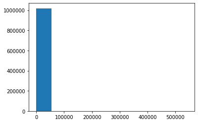

```python
plt.hist(data = df, x='duration');
```

This is not very helpful - there must be a small number of journeys pulling the x-axis across to the right, but not enough for any data to show up on the plot. Let's take a look at this programmatically.

```python
df['duration'].describe()
```

```
count    1.019888e+06
mean     1.310912e+03
std      4.117928e+03
min      6.000000e+01
25%      5.400000e+02
50%      9.000000e+02
75%      1.380000e+03
max      5.414400e+05
Name: duration, dtype: float64
```

This data's units is seconds. I will convert to minutes as I think it will make analysis easier

```python
df['duration'] = df['duration']/60.0
```

```python
df['duration'].describe()
```

```
count    1.019888e+06
mean     2.184853e+01
std      6.863213e+01
min      1.000000e+00
25%      9.000000e+00
50%      1.500000e+01
75%      2.300000e+01
max      9.024000e+03
Name: duration, dtype: float64
```

There are some significantly large outliers here, and some values which are so small they could be errors. I'll take a further look.

```python
df['duration'].sort_values()
```

```
104       1.0
107       1.0
21        1.0
107       1.0
68        1.0
        ...
39     8127.0
102    8173.0
93     8283.0
100    8928.0
15     9024.0
Name: duration, Length: 1019888, dtype: float64
```

After some consideration, I have decided to follow TfL's usage policy to govern where to remove outliers from my data. So for the purposes of this project, anything over 24hours (the maximum hire length) will be removed. I have also decided to remove any hires less than 1 minute, as this makes practical sense to me. I could have set some percentage limits (maybe 1% and 99%) as my cut-off points, but I feel that some short journey's would have been lost, and anything above 24hours is likely to be erroneous (eg, a bike was stolen).

```python
# Show how many rows I have before dropping data
df.shape
```

```
(1019888, 17)
```

```python
# Drop any durations above 24 hours (60mins * 24)
df = df[df.duration < 1440]
```

```python
# Drop any durations less than 1 minute
df = df[df.duration >= 1]
```

```python
df.shape
```

```
(1019625, 17)
```

```python
df['duration'].describe()
```

```
count    1.019625e+06
mean     2.105484e+01
std      3.954309e+01
min      1.000000e+00
25%      9.000000e+00
50%      1.500000e+01
75%      2.300000e+01
max      1.439000e+03
Name: duration, dtype: float64
```

Now let's relook at a histogram of duration after removing these values from the dataset

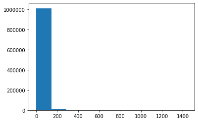

```python
plt.hist(data = df, x='duration');
```

Let's try a log transformation to see if we can make the duration data more interpretable

```python
dur = df['duration']
dur_log = np.log10(df['duration'])
```

```python
dur_log.describe()
```

```
count    1.019625e+06
mean     1.152617e+00
std      3.506010e-01
min      0.000000e+00
25%      9.542425e-01
50%      1.176091e+00
75%      1.361728e+00
max      3.158061e+00
Name: duration, dtype: float64
```

#### Histogram showing journey durations

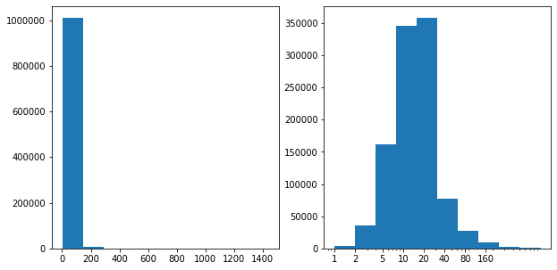

```python
plt.figure(figsize = [10, 5])

# left histogram: data plotted in natural units
plt.subplot(1, 2, 1);
plt.hist(dur);
#plt.xlabel('minutes')

# right histogram: data plotted after direct log transformation
plt.subplot(1, 2, 2)
bin_edges = 10**np.arange(0, dur_log.max()+0.1, 0.3);
plt.hist(dur, bins=bin_edges);
plt.xscale('log')
tick_locs = [1, 2, 5, 10, 20, 40, 80, 160]
plt.xticks(tick_locs, tick_locs);
#plt.xlabel('minutes');
```

After applying a log10 to the duration we can now see how the data lies, and this helps with the visualisation. I will conclude that the majoirty of the journey's made on these bikes are "short" in nature, eg less than 1 hour.

#### `2)` Let's look at days of the week

Now we know the nature of the trip lengths, I'm wondering how the data is spread across days of the week - Monday through to Sunday.

```python
df.info()
```

```
<class 'pandas.core.frame.DataFrame'>
Int64Index: 1019625 entries, 55 to 112
Data columns (total 17 columns):
 #   Column             Non-Null Count    Dtype
---  ------             --------------    -----
 0   rental_id          1019625 non-null  int64
 1   duration           1019625 non-null  float64
 2   bike_id            1019625 non-null  int64
 3   end_date           1019625 non-null  datetime64[ns]
 4   endstation_id      1019625 non-null  int64
 5   endstation_name    1019625 non-null  object
 6   start_date         1019625 non-null  datetime64[ns]
 7   startstation_id    1019625 non-null  int64
 8   startstation_name  1019625 non-null  object
 9   endstation_loc     1019625 non-null  object
 10  endstation_area    1019625 non-null  object
 11  startstation_loc   1019625 non-null  object
 12  startstation_area  1019625 non-null  object
 13  end_zone           1019625 non-null  int64
 14  end_compass        1019625 non-null  object
 15  start_zone         1019625 non-null  int64
 16  start_compass      1019625 non-null  object
dtypes: datetime64[ns](2), float64(1), int64(6), object(8)
memory usage: 140.0+ MB
```

```python
# Create a new column to store named day of the week
df['end_day'] = df['end_date'].dt.day_name()
```

```python
df['end_day'].value_counts()
```

```
Wednesday    168110
Monday       159752
Thursday     158204
Tuesday      155213
Friday       139189
Saturday     119942
Sunday       119215
Name: end_day, dtype: int64
```

Let's plot this as a bar chart to visualise the data

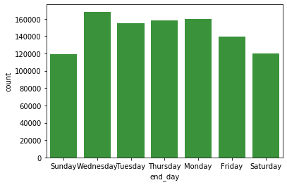

```python
# Plot this as a bar chart
base_color = sb.color_palette()[2]
sb.countplot(data = df, x = 'end_day', color=base_color);
```

This looks good, but days of the week are ordinal so i'll fix that

```python
# Set the ordinal levels, convert them to a category datatype and update the data to this type
level_order = ['Monday', 'Tuesday', 'Wednesday', 'Thursday', 'Friday', 'Saturday', 'Sunday']
ordered_cat = pd.api.types.CategoricalDtype(ordered = True, categories = level_order)
df['end_day'] = df['end_day'].astype(ordered_cat)
```

#### Most popular days of the week for journeys

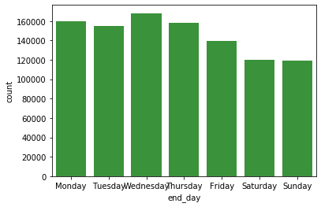

```python
# Replot
base_color = sb.color_palette()[2]
sb.countplot(data = df, x = 'end_day', color=base_color);
```

Interesting this shows that Wednesday is the most popular day of the week for bike hire. Here i'm making the assumption that journey's start and end on the same day, but this is probably unlikely. I'll do a quick programatic check to see how many journey's start and end on different days

```python
df['start_day'] = df['start_date'].dt.day_name()
```

```python
days_straddled = df.query('start_day != end_day')['end_day'].count()
```

```python
print(days_straddled)
print(days_straddled/len(df))
```

```
4778
0.004686036533039108
```

There were 4778 journeys which started and finished on different days, a percentage of less than 1%

#### `3)` Now let's look time of the day

```python
# Extract the start time (hour) and convert it to one of 6 time categories. Early morning is 4am-8am
df['start_time'] = (df['start_date'].dt.hour % 24 + 4) // 4
df['start_time'].replace({1: 'Late Night',
                      2: 'Early Morning',
                      3: 'Morning',
                      4: 'Noon',
                      5: 'Evening',
                      6: 'Night'}, inplace=True)
```

```python
df.sample(5)
```

|  | rental_id | duration | bike_id | end_date | endstation_id | endstation_name | start_date | startstation_id | startstation_name | endstation_loc | endstation_area | startstation_loc | startstation_area | end_zone | end_compass | start_zone | start_compass | end_day | start_day | start_time |
| --- | --- | --- | --- | --- | --- | --- | --- | --- | --- | --- | --- | --- | --- | --- | --- | --- | --- | --- | --- | --- |
| 26 | 89265224 | 30.0 | 3948 | 2019-07-20 18:27:00 | 76 | Longford Street, The Regent's Park | 2019-07-20 17:57:00 | 751 | Newton Street, Covent Garden | Longford Street | The Regent's Park | Newton Street | Covent Garden | 1 | central | 1 | central | Saturday | Saturday | Evening |
| 51 | 88584286 | 8.0 | 7921 | 2019-07-03 09:41:00 | 19 | Taviton Street, Bloomsbury | 2019-07-03 09:33:00 | 14 | Belgrove Street , King's Cross | Taviton Street | Bloomsbury | Belgrove Street | King's Cross | 1 | central | 1 | central | Wednesday | Wednesday | Morning |
| 80 | 88891553 | 26.0 | 14307 | 2019-07-10 19:12:00 | 192 | Wardour Street, Soho | 2019-07-10 18:46:00 | 628 | William Morris Way, Sands End | Wardour Street | Soho | William Morris Way | Sands End | 1 | central | 2 | south | Wednesday | Wednesday | Evening |
| 64 | 88939944 | 17.0 | 12581 | 2019-07-11 21:06:00 | 810 | Tate Modern, Bankside | 2019-07-11 20:49:00 | 199 | Great Tower Street, Monument | Tate Modern | Bankside | Great Tower Street | Monument | 1 | central | 1 | central | Thursday | Thursday | Night |
| 119 | 88992425 | 54.0 | 6824 | 2019-07-13 11:54:00 | 603 | Caldwell Street, Stockwell | 2019-07-13 11:00:00 | 633 | Vereker Road, West Kensington | Caldwell Street | Stockwell | Vereker Road | West Kensington | 2 | south | 1 | central | Saturday | Saturday | Morning |

```python
# Set the ordinal levels, convert them to a category datatype and update the data to this type
level_order = ['Early Morning', 'Morning', 'Noon', 'Evening', 'Night', 'Late Night']
ordered_cat = pd.api.types.CategoricalDtype(ordered = True, categories = level_order)
df['start_time'] = df['start_time'].astype(ordered_cat)
```

Let's plot this to visualise the data

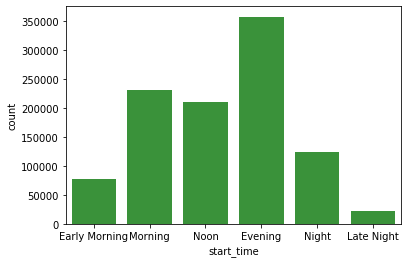

```python
# Plot this with a bar chart
base_color = sb.color_palette()[2]
sb.countplot(data = df, x = 'start_time', color=base_color);
```

Interestingly we see that mornings (8-12noon) and evenings (4-8pm) are the most popular times for bike hire. It would be interesting to see two bar charts side by side showing the same time splits on weekdays and at the weekend.

```python
# Create a new weekend column. True if Saturday or Sunday, False otherwise.
df['weekend'] = ((pd.DatetimeIndex(df['start_date']).dayofweek) // 5 == 1)
```

```python
df_weekend = df.query('weekend == True').copy()
df_weekday = df.query('weekend == False').copy()
```

```python
level_order = ['Early Morning', 'Morning', 'Noon', 'Evening', 'Night', 'Late Night']
ordered_cat = pd.api.types.CategoricalDtype(ordered = True, categories = level_order)
df_weekend['start_time'] = df_weekend['start_time'].astype(ordered_cat)
df_weekday['start_time'] = df_weekday['start_time'].astype(ordered_cat)
```

#### The most popular time of day for journeys, split weekdays / weekends

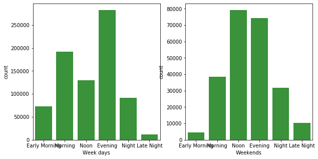

```python
plt.figure(figsize = [10, 5])
base_color = sb.color_palette()[2]

plt.subplot(1, 2, 1);
sb.countplot(data = df_weekday, x = 'start_time', color=base_color);
plt.xlabel("Week days");

plt.subplot(1, 2, 2);
sb.countplot(data = df_weekend, x = 'start_time', color=base_color);
plt.xlabel("Weekends");
```

The most popular time of day for bike journey's at the weekend is Noon, between 12-4pm.

We now have a good feel for when journey's are made, by day of the week and time of the day.

## Univariate analysis - summary

> Here i've looked at journey duration, along with the days and times of day that journey's were made.

### Discuss the distribution(s) of your variable(s) of interest. Were there any unusual points? Did you need to perform any transformations?

> The histogram of the duration was heavily right skewed, as most data tended towards shorter journey times of less than one hour. I decided to apply a log transformation to bring out the data at the lower end of the scale, and went further to remove any journey's over 24hours in length, as TfL do not allow journey's over 24 hours. I also removed any journeys of less than 1 minute. This gave me a much more intrepretable histogram which shows clear visual trends.

> Date and timing, once converted to a datetime data type, proved to be useful to analyse which days of the week, and which time of day, were most popular for journeys.

### Of the features you investigated, were there any unusual distributions? Did you perform any operations on the data to tidy, adjust, or change the form of the data? If so, why did you do this?

> The start and ending location data held a string with two pieces of information (eg, "Flamborough Street, Limehouse"). I used python's string splitting function to split this in to 2 separate data fields. This then allowed me to view all the journey's start/end locations from 123 different areas (eg, Limehouse is one area), and I was able to supplement the data with two new fields of Zone and Compass Area (eg, Limehouse is in East London, Zone 2). This feature engineering allowed me to aggregate my analysis over geographical areas, to bring out more trends in the data, as we see below.

## Bivariate Exploration

#### `1)` Start / end locations

It would be interesting to know where journey's start and end, but as there are so many possible combinations of docking station to docking station, it makes sense to use my compass categories to see a broad trend of where journey's start and end across the city.

```python
# How many docking stations are there?
df['startstation_id'].nunique()
```

```
787
```

```python
df.head()
```

|  | rental_id | duration | bike_id | end_date | endstation_id | endstation_name | start_date | startstation_id | startstation_name | endstation_loc | ... | startstation_loc | startstation_area | end_zone | end_compass | start_zone | start_compass | end_day | start_day | start_time | weekend |
| --- | --- | --- | --- | --- | --- | --- | --- | --- | --- | --- | --- | --- | --- | --- | --- | --- | --- | --- | --- | --- | --- |
| 55 | 88761782 | 11.0 | 4359 | 2019-07-07 17:06:00 | 464 | St. Mary & St. Michael Church, Stepney | 2019-07-07 16:55:00 | 510 | Westferry DLR, Limehouse | St. Mary & St. Michael Church | ... | Westferry DLR | Limehouse | 2 | east | 2 | east | Sunday | Sunday | Evening | True |
| 55 | 88610814 | 3.0 | 11502 | 2019-07-03 19:38:00 | 561 | Rectory Square, Stepney | 2019-07-03 19:35:00 | 480 | Flamborough Street, Limehouse | Rectory Square | ... | Flamborough Street | Limehouse | 2 | east | 2 | east | Wednesday | Wednesday | Evening | False |
| 55 | 88572877 | 6.0 | 12310 | 2019-07-03 06:14:00 | 500 | Ansell House, Stepney | 2019-07-03 06:08:00 | 480 | Flamborough Street, Limehouse | Ansell House | ... | Flamborough Street | Limehouse | 2 | east | 2 | east | Wednesday | Wednesday | Early Morning | False |
| 55 | 88840979 | 6.0 | 3562 | 2019-07-09 17:31:00 | 503 | Cleveland Way, Stepney | 2019-07-09 17:25:00 | 480 | Flamborough Street, Limehouse | Cleveland Way | ... | Flamborough Street | Limehouse | 2 | east | 2 | east | Tuesday | Tuesday | Evening | False |
| 55 | 88656383 | 4.0 | 2551 | 2019-07-04 19:38:00 | 561 | Rectory Square, Stepney | 2019-07-04 19:34:00 | 480 | Flamborough Street, Limehouse | Rectory Square | ... | Flamborough Street | Limehouse | 2 | east | 2 | east | Thursday | Thursday | Evening | False |

5 rows × 21 columns

Let's plot two bar charts side by side showing start / end locations by compass

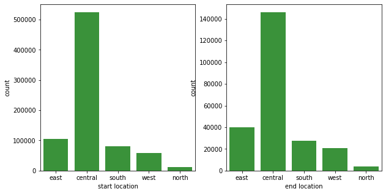

```python
plt.figure(figsize = [10, 5])
base_color = sb.color_palette()[2]

plt.subplot(1, 2, 1);
sb.countplot(data = df_weekday, x = 'start_compass', color=base_color);
plt.xlabel("start location");

plt.subplot(1, 2, 2);
sb.countplot(data = df_weekend, x = 'end_compass', color=base_color);
plt.xlabel("end location");
```

At a very high level this is useful - showing that the majority of journeys start and end in Central London. But it would be really interesting to know how these journey's mix and match, for example, how many journeys start in East London but end in Central London. I will use a Sankey Diagram to visualise this.

Used https://plotly.com/python/sankey-diagram/ to help plot the below

```python
# Count how many journeys start and end at each compass
compass_counts = df.groupby(['start_compass', 'end_compass']).size().reset_index(name='count')
compass_counts
```

|  | start_compass | end_compass | count |
| --- | --- | --- | --- |
| 0 | central | central | 517952 |
| 1 | central | east | 53131 |
| 2 | central | north | 13016 |
| 3 | central | south | 50529 |
| 4 | central | west | 36436 |
| 5 | east | central | 57775 |
| 6 | east | east | 83599 |
| 7 | east | north | 996 |
| 8 | east | south | 2210 |
| 9 | east | west | 476 |
| 10 | north | central | 13531 |
| 11 | north | east | 992 |
| 12 | north | north | 1650 |
| 13 | north | south | 276 |
| 14 | north | west | 261 |
| 15 | south | central | 49289 |
| 16 | south | east | 1680 |
| 17 | south | north | 214 |
| 18 | south | south | 44826 |
| 19 | south | west | 11161 |
| 20 | west | central | 35586 |
| 21 | west | east | 508 |
| 22 | west | north | 294 |
| 23 | west | south | 11989 |
| 24 | west | west | 31248 |

#### Where do journey's start and end?

```python
import plotly.graph_objects as go

fig = go.Figure(data=[go.Sankey(
    node = dict(
      pad = 15,
      thickness = 20,
      line = dict(color = "black", width = 0.5),
      label = ["Central", "East", "North", "South", "West", "Central", "East", "North", "South", "West"],
      color = "blue"
    ),
    link = dict(
      source = [0, 0, 0, 0, 0, 1, 1, 1, 1, 1, 2, 2, 2, 2, 2, 3, 3, 3, 3, 3, 4, 4, 4, 4, 4],
      target = [5, 6, 7, 8, 9, 5, 6, 7, 8, 9, 5, 6, 7, 8, 9, 5, 6, 7, 8, 9, 5, 6, 7, 8, 9],
      value = compass_counts['count'].tolist()
  ))])

fig.show()
```

[interactive chart not shown]

This is a really interesting visual, showing where journey's start and end in aggregate. However it is not particularly surprising that Central London is the start/end location for a large number of journeys, because that is where most of the docking stations are. Let's just check this data to confirm that assumption.

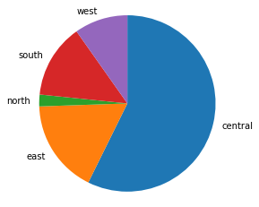

```python
station_counts = df.groupby('start_compass')['startstation_id'].nunique()
plt.pie(station_counts, labels = station_counts.index, startangle = 90,
        counterclock = False);
plt.axis('square');
```

It's true that most of the docking stations are in Central London, within zone 1. It looks to be well over 50%.

It would be useful to have percentage values added to the legend labels, plus titles. A bar chart may be a better visual.

```python
station_counts
```

```
start_compass
central    451
east       135
north       17
south      107
west        77
Name: startstation_id, dtype: int64
```

```python
df.sample(10)
```

|  | rental_id | duration | bike_id | end_date | endstation_id | endstation_name | start_date | startstation_id | startstation_name | endstation_loc | ... | startstation_loc | startstation_area | end_zone | end_compass | start_zone | start_compass | end_day | start_day | start_time | weekend |
| --- | --- | --- | --- | --- | --- | --- | --- | --- | --- | --- | --- | --- | --- | --- | --- | --- | --- | --- | --- | --- | --- |
| 103 | 88608660 | 6.0 | 5699 | 2019-07-03 19:03:00 | 94 | Bricklayers Arms, Borough | 2019-07-03 18:57:00 | 194 | Hop Exchange, The Borough | Bricklayers Arms | ... | Hop Exchange | The Borough | 1 | central | 2 | south | Wednesday | Wednesday | Evening | False |
| 60 | 88980898 | 8.0 | 2618 | 2019-07-12 20:17:00 | 109 | Soho Square , Soho | 2019-07-12 20:09:00 | 301 | Marylebone Lane, Marylebone | Soho Square | ... | Marylebone Lane | Marylebone | 1 | central | 1 | central | Friday | Friday | Night | False |
| 6 | 89092918 | 41.0 | 8108 | 2019-07-16 00:16:00 | 680 | Westbridge Road, Battersea | 2019-07-15 23:35:00 | 680 | Westbridge Road, Battersea | Westbridge Road | ... | Westbridge Road | Battersea | 2 | south | 2 | south | Tuesday | Monday | Night | False |
| 84 | 88618819 | 23.0 | 16143 | 2019-07-04 07:11:00 | 374 | Waterloo Station 1, Waterloo | 2019-07-04 06:48:00 | 486 | Granby Street, Shoreditch | Waterloo Station 1 | ... | Granby Street | Shoreditch | 1 | central | 1 | central | Thursday | Thursday | Early Morning | False |
| 36 | 88832532 | 9.0 | 16143 | 2019-07-09 14:00:00 | 99 | Old Quebec Street, Marylebone | 2019-07-09 13:51:00 | 357 | Howland Street, Fitzrovia | Old Quebec Street | ... | Howland Street | Fitzrovia | 1 | central | 1 | central | Tuesday | Tuesday | Noon | False |
| 69 | 89353873 | 8.0 | 15337 | 2019-07-23 07:04:00 | 446 | York Hall, Bethnal Green | 2019-07-23 06:56:00 | 721 | Wendon Street, Old Ford | York Hall | ... | Wendon Street | Old Ford | 2 | east | 2 | east | Tuesday | Tuesday | Early Morning | False |
| 30 | 89426791 | 21.0 | 6517 | 2019-07-24 18:14:00 | 121 | Baker Street, Marylebone | 2019-07-24 17:53:00 | 219 | Bramham Gardens, Earl's Court | Baker Street | ... | Bramham Gardens | Earl's Court | 1 | central | 1 | central | Wednesday | Wednesday | Evening | False |
| 88 | 88923972 | 5.0 | 16678 | 2019-07-11 16:22:00 | 230 | Poured Lines, Bankside | 2019-07-11 16:17:00 | 377 | Waterloo Bridge, South Bank | Poured Lines | ... | Waterloo Bridge | South Bank | 1 | central | 1 | central | Thursday | Thursday | Evening | False |
| 46 | 89491837 | 128.0 | 2323 | 2019-07-26 14:09:00 | 130 | Tower Gardens , Tower | 2019-07-26 12:01:00 | 303 | Albert Gate, Hyde Park | Tower Gardens | ... | Albert Gate | Hyde Park | 1 | central | 1 | central | Friday | Friday | Noon | False |
| 67 | 88639307 | 5.0 | 3685 | 2019-07-04 15:11:00 | 807 | Bevington Road West, North Kensington | 2019-07-04 15:06:00 | 650 | St. Mark's Road, North Kensington | Bevington Road West | ... | St. Mark's Road | North Kensington | 1 | central | 1 | central | Thursday | Thursday | Noon | False |

10 rows × 21 columns

So we can compare areas outside of Central London, i'll plot another pie chart to depict the number of docking stations in North, East, South and West London

```python
z2station_counts = df.groupby('start_compass')['startstation_id'].nunique()
z2station_counts = z2station_counts.drop('central')
```

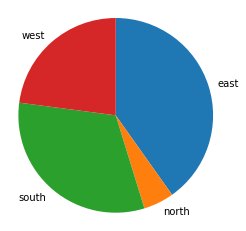

```python
plt.pie(z2station_counts, labels = z2station_counts.index, startangle = 90,
        counterclock = False);
plt.axis('square');
```

This is actually probably better plotted as a bar chart with the values shown as labels

```python
z2station_counts.sort_values(ascending=False, inplace=True)
```

#### The number of docking stations in different parts of the city (outside of Central London)

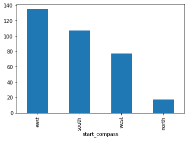

```python
z2station_counts.plot.bar();
```

So it looks like North London has many fewer docking stations than other areas of London, with East London having the most. I wonder how many journey's are made, on average, from these docking stations each day. I will build a new dataframe to create a scatter plot to visualise this. On the x-axis I want average number of journey's made from each docking station. On the y-axis can be average duration of journeys made from each docking station. And I will create a third variable encoding by colouring the scatter points plotted to depict whether the docking station is in North, East, South or West London.

## Bivariate analysis - summary

> In this section I looked at the relationship between number of journeys which started and ended in different compass areas of the city. I then looked at the number of docking stations per area.

### Did you observe any interesting relationships between the other features (not the main feature(s) of interest)?

> It was surprising to see how few docking stations there are in North London, and this led me onto my next set of analyses.

## Multivariate Exploration

With relatively fewer docking stations, I wanted to see if North Londoner's have a higher utilisation rate, by showing the average number of journey's started per day from the 4 compass areas.

```python
# Extract journeys which start outside of Central London into a new df
z2_df = df.query('start_compass == ["north", "east", "south", "west"]').copy()
z2_df.shape
```

```
(348561, 21)
```

```python
# Find the daily average number of journeys started from each docking station
daily_av_jour = z2_df.groupby('startstation_id')['rental_id'].nunique() / 28 #number of days
daily_av_jour.describe()
```

```
count    336.000000
mean      37.049426
std       22.561293
min        3.285714
25%       22.758929
50%       34.035714
75%       45.178571
max      193.857143
Name: rental_id, dtype: float64
```

```python
daily_av_jour
```

```
startstation_id
8      43.785714
30     46.035714
31     46.000000
42     52.714286
46     93.250000
         ...
830    27.392857
831    20.964286
832    42.107143
833    32.464286
834    31.642857
Name: rental_id, Length: 336, dtype: float64
```

```python
# Find the daily average duration of journeys started from each docking station
daily_av_dur = z2_df.groupby('startstation_id')['duration'].mean()
daily_av_dur.describe()
```

```
count    336.000000
mean      20.594815
std        5.784678
min       12.183246
25%       16.856648
50%       19.138644
75%       22.966660
max       47.151990
Name: duration, dtype: float64
```

```python
# Extract the compass (North, South, East, West) for each docking station into a new df
start_compasses = z2_df['start_compass'].groupby(z2_df['startstation_id']).unique().apply(pd.Series)
start_compasses = start_compasses.rename(columns={0:"compass"})
start_compasses.index.names = ['startstation_id']
```

```python
# Build a new df for the scatter plot by merging the above
scatter_df = start_compasses.merge(daily_av_dur, left_index=True, right_index=True)
scatter_df = scatter_df.merge(daily_av_jour, left_index=True, right_index=True)
scatter_df = scatter_df.rename(columns={"rental_id":"journeys"})
```

Now I have wrangled my data in to a scatter dataframe I can draw the plot. I will show average number of journeys per day on the x axis, vs average duration of journey's made from each docking station. A third variable, encoded with coloured markers, shows where abouts in London the docking station is

#### Average duration & average number of journey's per day, by docking station, by compass area

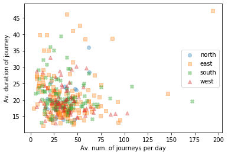

```python
cat_markers = [['north', 'o'],
               ['east', 's'],
               ['south', 'X'],
               ['west', '^']]

for cat, marker in cat_markers:
    df_cat = scatter_df[scatter_df['compass'] == cat]
    plt.scatter(data = df_cat, x = 'journeys', y = 'duration', marker = marker, alpha=1/3)

plt.legend(['north','east','south','west'])
plt.xlabel("Av. num. of journeys per day");
plt.ylabel("Av. duration of journey");
```

This is an interesting chart but is perhaps too busy to make much visual analysis of the differences between the journeys made from North, East, South or East London.

A more insightful visualisation would be average number of journeys made from each docking station, by compass, and therefore dropping the average duration data. With one less variable to plot I will show this in a violin plot.

#### Average number of journeys per day, by compass area

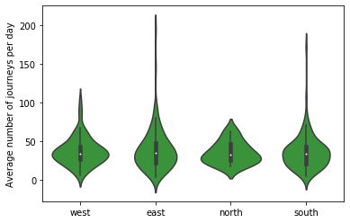

```python
sb.violinplot(data = scatter_df, x = 'compass', y = 'journeys', color = base_color);
plt.ylabel("Average number of journeys per day");
plt.xlabel("");
```

```python
scatter_df.groupby('compass')['journeys'].describe()
```

| compass | count | mean | std | min | 25% | 50% | 75% | max |
| --- | --- | --- | --- | --- | --- | --- | --- | --- |
| east | 135.0 | 38.374603 | 25.948499 | 3.285714 | 22.357143 | 34.357143 | 47.339286 | 193.857143 |
| north | 17.0 | 35.105042 | 14.081603 | 17.821429 | 25.107143 | 33.000000 | 46.892857 | 62.750000 |
| south | 107.0 | 35.771028 | 22.174289 | 5.071429 | 21.303571 | 33.250000 | 42.535714 | 171.892857 |
| west | 77.0 | 36.931818 | 17.963215 | 6.285714 | 26.428571 | 33.964286 | 43.071429 | 102.821429 |

### Were there any interesting or surprising interactions between features?

> The violin plot shows that the average number of journey's per day from each docking station, grouped by compass area, was about the same, in the range of 35-38 journeys per docking station per day. Interestingly, the docking stations in North London had a minimum average usage per day of 17 journeys. The nearest competitor to this was West London's docking stations with an average minimum of just 6 journeys per day.

> This is shown in the visualisation by the lack of a tail to the North's plot. This shows that, although North London has fewer docking stations, they are very well utilised, and I suspect they need to be restocked quite quickly throughout peak commuter hours. North London might be in line for an expansion in it's docking stations in the near future - properties close to new docking stations could be seeing an increase in value!

## Additional Bivariate Analysis

#### COVID-19 and the effect of Lockdown on London

I will plot a time series line chart to show the number of Boris Bike hire's started per day over 2019 and into 2020. TfL have provided data up until 26th May 2020. I will need to load in the csv's I downloaded at the beginning of this notebook and extract the required date count information into a smaller dataframe.

```python
# Load the csv files in to a dataframe
# Please copy all files from 2019 and 2020 folders into a new folder called source_data_1920
filepaths = os.listdir("./source_data_1920")
d = './source_data_1920'
filepaths = [os.path.join(d, o) for o in os.listdir(d)]

df_lockdown = pd.concat(map(pd.read_csv, filepaths))
```

```python
# 2019 and 2020 combined is over 13million journeys
df_lockdown.shape
```

```
(13704756, 10)
```

```python
# I only want the dates from the Start Date, so i'll take the first 10 characters
# Note, converting this field to a Datetime type takes took long on my machine
just_dates = df_lockdown['Start Date'].str[:10]
```

```python
# Create a new dataframe with count of all journeys started per day
df10 = just_dates.value_counts().rename_axis('days').reset_index(name='counts')
```

```python
# Now convert this to a datetime type, for easier analysis
df10['days'] = pd.to_datetime(df10['days'], dayfirst=True)
```

Let's plot this using a line chart to visualise the trend

#### Journeys per day

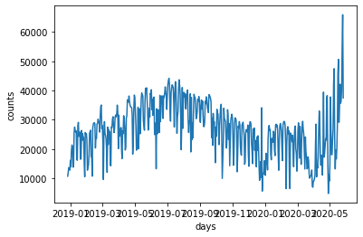

```python
# Plot it and see
sb.lineplot(x="days", y="counts", data=df10);
```

This is too difficult to read with too many datapoints - I'll resample my data to have weekly counts rather than daily

```python
# Resample dates to a weekly basis, then replot
df7 = df10.resample('W-TUE', on='days').sum().reset_index()
df7.rename(columns={"days":"week_ending"}, inplace=True)
```

Replot the chart but using weekly data rather than daily

#### Journey's per week

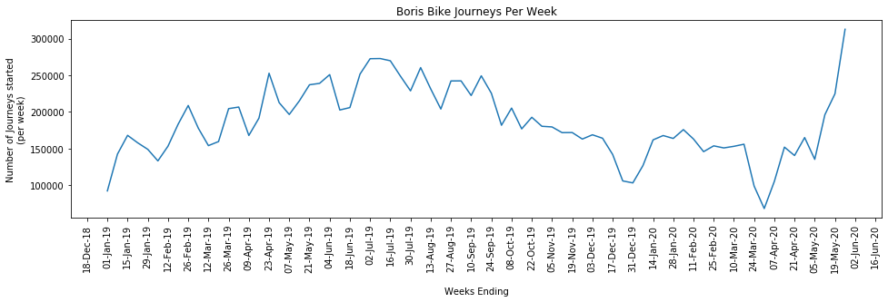

```python
from matplotlib.dates import DateFormatter
import matplotlib.dates as mdates

# Create figure and plot space
fig, ax = plt.subplots(figsize=(16, 4))

# Add plot
sb.lineplot(data=df7, x="week_ending", y="counts");

# Set title and labels for axes
ax.set(xlabel="\nWeeks Ending",
       ylabel="Number of Journeys started\n(per week)",
       title="Boris Bike Journeys Per Week");

# Define the date format
date_form = DateFormatter("%d-%b-%y")
ax.xaxis.set_major_formatter(date_form)

# Ensure a major tick for each week using (interval=1)
ax.xaxis.set_major_locator(mdates.WeekdayLocator(interval=2))
plt.xticks(rotation=90);

plt.show()
```

This is a fascinating chart which shows the significant decrease in cycle journeys as the UK Lockdown began on 23rd March. We can see significant decreases in journeys made as the lockdown comes in to force, and for the week ending 31st March there were 68,184 journeys made across London. At the same time last year there was around 200,000. Interestingly the number of journeys made then begins to increase in April, however not to "normal" April levels as per 2019. Perhaps this was down to people using Boris Bikes to commute instead of trains, tubes and buses, while significant numbers of London's residents were locked down.

The UK's Lockdown measures were eased on 11th May, and from this date we can see the number of journeys taken on Boris Bikes spikes significantly. In the week ending 26th May a high of 312,668 journeys was made in one week.

```python
df7.nsmallest(5, 'counts')
```

|  | week_ending | counts |
| --- | --- | --- |
| 65 | 2020-03-31 | 68184 |
| 0 | 2019-01-01 | 92225 |
| 64 | 2020-03-24 | 98833 |
| 52 | 2019-12-31 | 103151 |
| 66 | 2020-04-07 | 105147 |

```python
df7.nlargest(5, 'counts')
```

|  | week_ending | counts |
| --- | --- | --- |
| 73 | 2020-05-26 | 312668 |
| 27 | 2019-07-09 | 272750 |
| 26 | 2019-07-02 | 272524 |
| 28 | 2019-07-16 | 269718 |
| 31 | 2019-08-06 | 260386 |

Ends